# 【TaskC】Handling missing values

##### !!! please DO NOT rename this file !!!

### 【TaskC】Dealing with missing values

- student id:111522019
- name：黃煒翔

### 此次任務中一共有兩份資料集，一份是完整的資料，一份是有遺漏值的資料，如下所示：

### There are two datasets in this task. One is the complete data and the other is the data with missing value:

```
- 完整資料/complete data：'StudentsPerformance.csv'
- 有遺漏值/with missing values：'StudentsPerformance_miss.csv'
```

#### 【Q1】在第一題中，請使用「有遺漏值」的資料完成以下任務：

##### 1. 在有遺漏值的檔案中，遺漏值並不是以空值nan的形式呈現，請撰寫程式來確認此份資料是以什麼符號表示遺漏值，並附上執行過程

##### 2. 若遺漏值不是nan形式，會無法執行pandas的遺漏值函式。因此，請將檔案中的遺漏值轉換成nan的形式，並附上執行過程

##### 3. 請找出此份資料中哪幾個欄位有遺漏值，及遺漏值的數量，並附上執行過程

#### 【Q1】In question1, please use dataset "with missing value" to finish the following tasks：

##### 1. In the file with missing value, missing values are not presented as nan. Please write code to check out which character are use to present the missing value.(must show how you do it)

##### 2. Please transfer the missing value into nan.(must show how you do it)

##### 3. Please find out which columns have missing values and the amount of missing value.(must show how you do it)

```python
import pandas as pd
import numpy as np
import matplotlib.pyplot as plt

plt.style.use('ggplot')
# https://matplotlib.org/gallery/style_sheets/style_sheets_reference.html
%matplotlib inline
dfSP = pd.read_csv('StudentsPerformance_miss.csv')
```

```python
dfSP.info()
# 推測三欄 score 有 missing value
```

```
<class 'pandas.core.frame.DataFrame'>
RangeIndex: 1000 entries, 0 to 999
Data columns (total 9 columns):
 #   Column                       Non-Null Count  Dtype
---  ------                       --------------  -----
 0   Unnamed: 0                   1000 non-null   int64
 1   gender                       1000 non-null   object
 2   race/ethnicity               1000 non-null   object
 3   parental level of education  1000 non-null   object
 4   lunch                        1000 non-null   object
 5   test preparation course      1000 non-null   object
 6   math_score                   1000 non-null   object
 7   reading_score                1000 non-null   object
 8   writing_score                1000 non-null   object
dtypes: int64(1), object(8)
memory usage: 70.4+ KB
```

# Q1.1

```python
display(dfSP.head())
#推測 missing value 是用 * 表示
```

|  | Unnamed: 0 | gender | race/ethnicity | parental level of education | lunch | test preparation course | math_score | reading_score | writing_score |
| --- | --- | --- | --- | --- | --- | --- | --- | --- | --- |
| 0 | 0 | female | group B | bachelor's degree | standard | none | 72 | 72 | 74 |
| 1 | 1 | female | group C | some college | standard | completed | 69 | 90 | 88 |
| 2 | 2 | female | group B | master's degree | standard | none | 90 | 95 | 93 |
| 3 | 3 | male | group A | associate's degree | free/reduced | none | 47 | * | 44 |
| 4 | 4 | male | group C | some college | standard | none | 76 | 78 | 75 |

```python
math_score_unique = dfSP.math_score.unique()
np.sort(math_score_unique)
```

```
array(['*', '0', '100', '18', '19', '22', '23', '26', '27', '28', '29',
       '30', '32', '33', '34', '35', '36', '37', '38', '39', '40', '41',
       '42', '43', '44', '45', '46', '47', '48', '49', '50', '51', '52',
       '53', '54', '55', '56', '57', '58', '59', '60', '61', '62', '63',
       '64', '65', '66', '67', '68', '69', '70', '71', '72', '73', '74',
       '75', '76', '77', '78', '79', '8', '80', '81', '82', '83', '84',
       '85', '86', '87', '88', '89', '90', '91', '92', '93', '94', '95',
       '96', '97', '98', '99'], dtype=object)
```

math_score 的 missing value 用 * 表示

```python
reading_score_unique = dfSP.reading_score.unique()
np.sort(reading_score_unique)
```

```
array(['*', '100', '17', '23', '24', '26', '28', '29', '31', '32', '34',
       '37', '38', '39', '40', '41', '42', '43', '44', '45', '46', '47',
       '48', '49', '50', '51', '52', '53', '54', '55', '56', '57', '58',
       '59', '60', '61', '62', '63', '64', '65', '66', '67', '68', '69',
       '70', '71', '72', '73', '74', '75', '76', '77', '78', '79', '80',
       '81', '82', '83', '84', '85', '86', '87', '88', '89', '90', '91',
       '92', '93', '94', '95', '96', '97', '99'], dtype=object)
```

reading_score 的 missing value 用 * 表示

```python
writing_score_unique = dfSP.writing_score.unique()
np.sort(writing_score_unique)
```

```
array(['*', '100', '15', '19', '22', '23', '27', '28', '30', '32', '33',
       '34', '35', '36', '37', '38', '39', '40', '41', '42', '43', '44',
       '45', '46', '47', '48', '49', '50', '51', '52', '53', '54', '55',
       '56', '57', '58', '59', '60', '61', '62', '63', '64', '65', '66',
       '67', '68', '69', '70', '71', '72', '73', '74', '75', '76', '77',
       '78', '79', '80', '81', '82', '83', '84', '85', '86', '87', '88',
       '89', '90', '91', '92', '93', '94', '95', '96', '97', '98', '99'],
      dtype=object)
```

writing_score 的 missing value 用 * 表示

# Q1.2

```python
dfSP_nan = pd.read_csv('StudentsPerformance_miss.csv', na_values = '*')
dfSP_nan.info()
```

```
<class 'pandas.core.frame.DataFrame'>
RangeIndex: 1000 entries, 0 to 999
Data columns (total 9 columns):
 #   Column                       Non-Null Count  Dtype
---  ------                       --------------  -----
 0   Unnamed: 0                   1000 non-null   int64
 1   gender                       1000 non-null   object
 2   race/ethnicity               1000 non-null   object
 3   parental level of education  1000 non-null   object
 4   lunch                        1000 non-null   object
 5   test preparation course      1000 non-null   object
 6   math_score                   950 non-null    float64
 7   reading_score                923 non-null    float64
 8   writing_score                944 non-null    float64
dtypes: float64(3), int64(1), object(5)
memory usage: 70.4+ KB
```

三欄 score 皆已處理 missing value

```python
dfSP_nan.head()
```

|  | Unnamed: 0 | gender | race/ethnicity | parental level of education | lunch | test preparation course | math_score | reading_score | writing_score |
| --- | --- | --- | --- | --- | --- | --- | --- | --- | --- |
| 0 | 0 | female | group B | bachelor's degree | standard | none | 72.0 | 72.0 | 74.0 |
| 1 | 1 | female | group C | some college | standard | completed | 69.0 | 90.0 | 88.0 |
| 2 | 2 | female | group B | master's degree | standard | none | 90.0 | 95.0 | 93.0 |
| 3 | 3 | male | group A | associate's degree | free/reduced | none | 47.0 | NaN | 44.0 |
| 4 | 4 | male | group C | some college | standard | none | 76.0 | 78.0 | 75.0 |

確認已用 NaN 取代 missing value

# Q1.3

```python
dfSP_nan.isna().any()
#math_score, reading_score, writing_score三個欄位有 missing value
```

```
Unnamed: 0                     False
gender                         False
race/ethnicity                 False
parental level of education    False
lunch                          False
test preparation course        False
math_score                      True
reading_score                   True
writing_score                   True
dtype: bool
```

```python
print(dfSP_nan.math_score.isna().sum())
#math_score 共 50 個  missing value
```

```
50
```

```python
dfSP_nan.math_score[np.isnan(dfSP_nan.math_score)]
#math_score 的這些欄位有 missing value
```

```
20    NaN
33    NaN
41    NaN
62    NaN
63    NaN
68    NaN
71    NaN
79    NaN
102   NaN
160   NaN
172   NaN
185   NaN
191   NaN
200   NaN
244   NaN
```

[output cut: 36 more lines]

```python
print(dfSP_nan.reading_score.isna().sum())
#reading_score 共 77 個  missing value
```

```
77
```

```python
dfSP_nan.reading_score[np.isnan(dfSP_nan.reading_score)]
#reading_score 的這些欄位有 missing value
```

```
3     NaN
9     NaN
27    NaN
34    NaN
45    NaN
       ..
933   NaN
942   NaN
976   NaN
986   NaN
992   NaN
Name: reading_score, Length: 77, dtype: float64
```

```python
print(dfSP_nan.writing_score.isna().sum())
#writing_score 共 56 個  missing value
```

```
56
```

```python
dfSP_nan.writing_score[np.isnan(dfSP_nan.writing_score)]
#writing_score 的這些欄位有 missing value
```

```
5     NaN
15    NaN
24    NaN
59    NaN
61    NaN
74    NaN
122   NaN
135   NaN
189   NaN
211   NaN
216   NaN
224   NaN
229   NaN
251   NaN
268   NaN
```

[output cut: 42 more lines]

#### 【Q2】請延續第一題的結果，完成以下任務：

##### 1. 對遺漏值進行處理(e.g.移除遺漏值、填補遺漏值等等)，並透過註解說明你處理遺漏值的方法

##### 2. 請透過pandas函式(statistic function、groupby等等)比較「完整資料」與你「處理完的有遺漏值的」資料在分數上的差異

##### 3. 請透過pandas函式(statistic function、groupby...)對完整的資料進行分析，並提出至少3個結論

##### 請使用註解或remark說明你的結論

#### 【Q2】Please use the results of question1 and complete the following tasks:

##### 1. Deal with the missing values(e.g.remove, fill...), and use remark to explain how you handle missing values.

##### 2. Use pandas function(statistic function、groupby...) to compare the score difference between "complete data" and "data with missing values" you "already finsh handling".

##### 3. Use pandas function(statistic function、groupby...)to analysis the "complete data" and come up with at least 3 conclusions.

##### remark or Markdown to explain your conclusion.

# Q.3.1

```python
#方法一 刪除含有 missing value 的 index
dfSP_delete = dfSP_nan.dropna(how = 'any')
dfSP_delete.isna().any()
```

```
Unnamed: 0                     False
gender                         False
race/ethnicity                 False
parental level of education    False
lunch                          False
test preparation course        False
math_score                     False
reading_score                  False
writing_score                  False
dtype: bool
```

確認皆不含 missing value

```python
#方法二 將 missing value 用 中位數填充
dfSP_median = dfSP_nan.copy()
dfSP_median.math_score.replace(np.nan,  dfSP_nan.math_score.quantile(0.5), inplace = True)
dfSP_median.reading_score.replace(np.nan,  dfSP_nan.reading_score.quantile(0.5), inplace = True)
dfSP_median.writing_score.replace(np.nan,  dfSP_nan.writing_score.quantile(0.5), inplace = True)
dfSP_median.isna().any()
```

```
Unnamed: 0                     False
gender                         False
race/ethnicity                 False
parental level of education    False
lunch                          False
test preparation course        False
math_score                     False
reading_score                  False
writing_score                  False
dtype: bool
```

確認皆不含 missing value

```python
#方法三 使用線性補值
dfSP_interpolate = dfSP_nan.copy()
dfSP_interpolate.math_score.interpolate(method = 'linear', inplace = True)
dfSP_interpolate.reading_score.interpolate(method = 'linear', inplace = True)
dfSP_interpolate.writing_score.interpolate(method = 'linear', inplace = True)
dfSP_interpolate.isna().any()
```

```
Unnamed: 0                     False
gender                         False
race/ethnicity                 False
parental level of education    False
lunch                          False
test preparation course        False
math_score                     False
reading_score                  False
writing_score                  False
dtype: bool
```

確認皆不含 missing value

# Q.3.2

```
complete_math_mean:  66.089
complete_reading_mean:  69.169
complete_writing_mean:  68.054
```

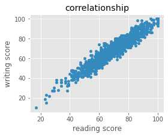

```python
#no missing data mean
dfSP_nomiss = pd.read_csv('StudentsPerformance.csv')
print("complete_math_mean: ",dfSP_nomiss['math score'].mean())
print("complete_reading_mean: ",dfSP_nomiss['reading score'].mean())
print("complete_writing_mean: ",dfSP_nomiss['writing score'].mean())
dfSP_nomiss.plot(kind='scatter',title='correlationship',figsize=(4,3),x='reading score',y='writing score',marker='o')
```

```
delete_math_mean:  65.87760097919217
delete_reading_mean:  69.31946144430844
delete_writing_mean:  68.27294981640146
```

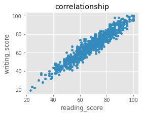

```python
#delete missing data mean
print("delete_math_mean: ",dfSP_delete['math_score'].mean())
print("delete_reading_mean: ",dfSP_delete['reading_score'].mean())
print("delete_writing_mean: ",dfSP_delete['writing_score'].mean())
dfSP_delete.plot(kind='scatter',title='correlationship',figsize=(4,3),x='reading_score',y='writing_score',marker='o')
```

```
delete_math_median:  66.08
delete_reading_median:  69.224
delete_writing_median:  68.208
```

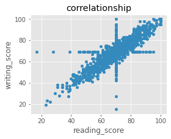

```python
#median missing data mean
print("delete_math_median: ",dfSP_median['math_score'].mean())
print("delete_reading_median: ",dfSP_median['reading_score'].mean())
print("delete_writing_median: ",dfSP_median['writing_score'].mean())
dfSP_median.plot(kind='scatter',title='correlationship',figsize=(4,3),x='reading_score',y='writing_score',marker='o')
```

```
delete_math_interpolate:  65.9015
delete_reading_interpolate:  69.04
delete_writing_interpolate:  68.219
```

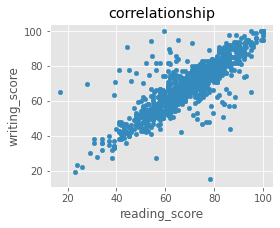

```python
#interpolate missing data mean
print("delete_math_interpolate: ",dfSP_interpolate['math_score'].mean())
print("delete_reading_interpolate: ",dfSP_interpolate['reading_score'].mean())
print("delete_writing_interpolate: ",dfSP_interpolate['writing_score'].mean())
dfSP_interpolate.plot(kind='scatter',title='correlationship',figsize=(4,3),x='reading_score',y='writing_score',marker='o')
```

## 在三個score的mean中，使用median填補missing value的方法皆與原始值差距最小。

```python
#no missing data correlation matrix
print(dfSP_nomiss[['math score','reading score','writing score']].corr())
```

|  | math score | reading score | writing score |
| --- | --- | --- | --- |
| math score | 1.000000 | 0.817580 | 0.802642 |
| reading score | 0.817580 | 1.000000 | 0.954598 |
| writing score | 0.802642 | 0.954598 | 1.000000 |

```python
#no missing data correlation matrix
print(dfSP_delete[['math_score','reading_score','writing_score']].corr())
```

|  | math_score | reading_score | writing_score |
| --- | --- | --- | --- |
| math_score | 1.000000 | 0.814449 | 0.794475 |
| reading_score | 0.814449 | 1.000000 | 0.953759 |
| writing_score | 0.794475 | 0.953759 | 1.000000 |

```python
#no missing data correlation matrix
print(dfSP_median[['math_score','reading_score','writing_score']].corr())
```

|  | math_score | reading_score | writing_score |
| --- | --- | --- | --- |
| math_score | 1.000000 | 0.756214 | 0.739984 |
| reading_score | 0.756214 | 1.000000 | 0.875811 |
| writing_score | 0.739984 | 0.875811 | 1.000000 |

```python
#no missing data correlation matrix
dfSP_interpolate[['math_score','reading_score','writing_score']].corr()
```

|  | math_score | reading_score | writing_score |
| --- | --- | --- | --- |
| math_score | 1.000000 | 0.718354 | 0.722099 |
| reading_score | 0.718354 | 1.000000 | 0.838358 |
| writing_score | 0.722099 | 0.838358 | 1.000000 |

## 而在三個score的correlation中，刪除missing value的方法皆與原始值差距最小。

# Q.3.3

```python
# 檢查及格人數

# 先把不及格的欄位移除
pass_data = dfSP_nomiss
pass_data["math score"] = pass_data["math score"].where(dfSP_nomiss["math score"] > 60)
pass_data["reading score"] = pass_data["reading score"].where(dfSP_nomiss["reading score"] > 60)
pass_data["writing score"] = pass_data["writing score"].where(dfSP_nomiss["writing score"] > 60)
pass_data
```

|  | gender | race/ethnicity | parental level of education | lunch | test preparation course | math score | reading score | writing score |
| --- | --- | --- | --- | --- | --- | --- | --- | --- |
| 0 | female | group B | bachelor's degree | standard | none | 72.0 | 72.0 | 74.0 |
| 1 | female | group C | some college | standard | completed | 69.0 | 90.0 | 88.0 |
| 2 | female | group B | master's degree | standard | none | 90.0 | 95.0 | 93.0 |
| 3 | male | group A | associate's degree | free/reduced | none | NaN | NaN | NaN |
| 4 | male | group C | some college | standard | none | 76.0 | 78.0 | 75.0 |
| ... | ... | ... | ... | ... | ... | ... | ... | ... |
| 995 | female | group E | master's degree | standard | completed | 88.0 | 99.0 | 95.0 |
| 996 | male | group C | high school | free/reduced | none | 62.0 | NaN | NaN |
| 997 | female | group C | high school | free/reduced | completed | NaN | 71.0 | 65.0 |
| 998 | female | group D | some college | standard | completed | 68.0 | 78.0 | 77.0 |
| 999 | female | group D | some college | free/reduced | none | 77.0 | 86.0 | 86.0 |

1000 rows × 8 columns

```
gender                         1000
race/ethnicity                 1000
parental level of education    1000
lunch                          1000
test preparation course        1000
math score                      661
reading score                   725
writing score                   699
dtype: int64
```

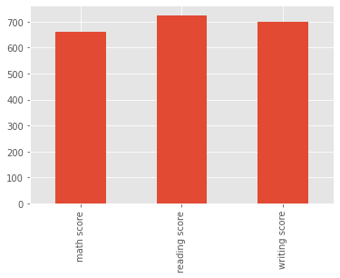

```python
# 後三項為各科總及格人數
print( pass_data.count() )
pass_data[["math score", "reading score", "writing score"]].count().plot( kind="bar" )
```

```python
dfSP_nomiss.groupby('gender').mean()
```

| gender | math score | reading score | writing score |
| --- | --- | --- | --- |
| female | 63.633205 | 72.608108 | 72.467181 |
| male | 68.728216 | 65.473029 | 63.311203 |

```python
dfSP_nomiss.groupby('lunch').mean()
```

| lunch | math score | reading score | writing score |
| --- | --- | --- | --- |
| free/reduced | 58.921127 | 64.653521 | 63.022535 |
| standard | 70.034109 | 71.654264 | 70.823256 |

午餐為standard的人，在三個科目的表現都比較好。

```python
dfSP_nomiss.groupby('gender').std()
```

| gender | math score | reading score | writing score |
| --- | --- | --- | --- |
| female | 15.491453 | 14.378245 | 14.844842 |
| male | 14.356277 | 13.931832 | 14.113832 |

在三個科目中女生的standard deviation都比較高，代表女生成績好壞差距比較大。

```python
display(dfSP_nomiss.groupby(['test preparation course','gender']).mean())
```

| test preparation course | gender | math score | reading score | writing score |
| --- | --- | --- | --- | --- |
| completed | female | 74.468254 | 80.103030 | 80.941176 |
|  | male | 77.510791 | 76.151515 | 75.653846 |
| none | female | 72.673797 | 75.941176 | 75.697581 |
|  | male | 74.181818 | 72.260116 | 70.735099 |

不論男女，有上備考課程的平均成績都高於沒有上過課程的平均成績

```python
display(dfSP_nomiss.groupby('parental level of education').mean())
```

| parental level of education | math score | reading score | writing score |
| --- | --- | --- | --- |
| associate's degree | 76.290541 | 76.769231 | 76.685185 |
| bachelor's degree | 75.318681 | 77.778947 | 78.216495 |
| high school | 72.081081 | 73.504065 | 72.336283 |
| master's degree | 77.619048 | 79.428571 | 79.176471 |
| some college | 74.159236 | 75.666667 | 75.945122 |
| some high school | 73.232143 | 75.429752 | 74.750000 |

當父母的學歷是碩士的時候，各科的平均成績都是最高的